# Chaos Game

Duduman Cristian, Moisii Lucian, Pomparau Renato-Emil

2023-02-01

## Prezentare:

În matematică, termenul joc de haos a fost introdus în 1993 de Michael Barnsley .

Inițial, aceasta a fost o metodă rapidă și ușoară de a crea fractali folosind un poligon și un punct de plecare ales aleatoriu în interiorul acelui poligon. Fractalul este creat prin crearea, prin iterații succesive, a unei secvențe de puncte, pornind de la un punct inițial ales aleatoriu, pentru care fiecare punct al secvenței este poziționat la o fracție dată a distanței care separă punctul anterior de unul dintre vârfuri a poligonului. Acest vârf este ales aleatoriu la fiecare iterație. Repetând acest proces de un număr semnificativ de ori și ignorând primele puncte din secvență, un model fractal va apărea în majoritatea cazurilor.

## Interfata:

- *Shape*: Meniu dropdown pentru alegerea poligonului in cadrul caruia se va genera fractalul.
- *Distance ratio to endpoint*: Proportia pe baza careia va fi ales urmatorul punct in raport cu distanta de la punctul curent si varful ales aleator
- *Default value*: Distance ratio-ul indicat pentru fractalul ales.
- *Size*: Intervalul in care se va situa numarul de puncte generate de plot.
- *Number of points*: Slider prin care se alege numarul de puncte generate de plot.

## Exemple de fractale:

Triunghi

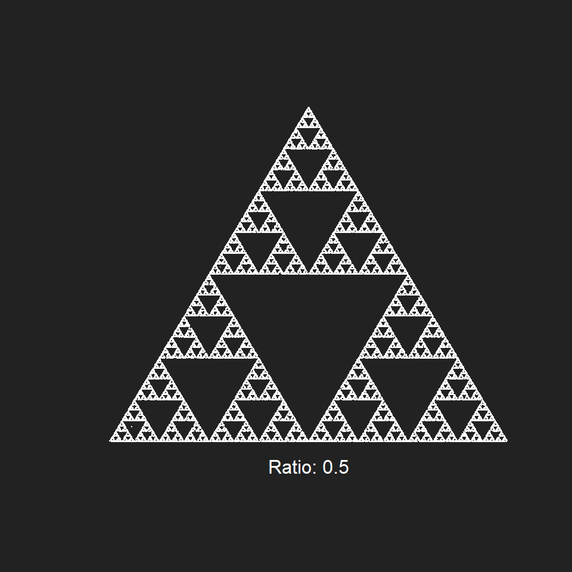

Patrat

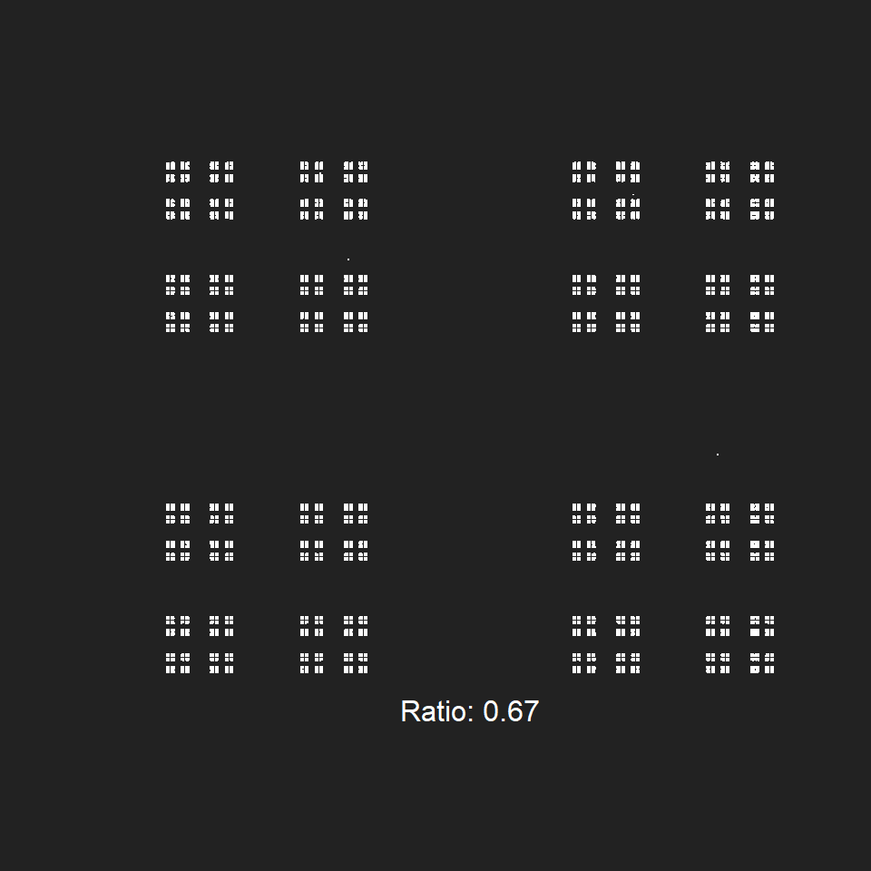

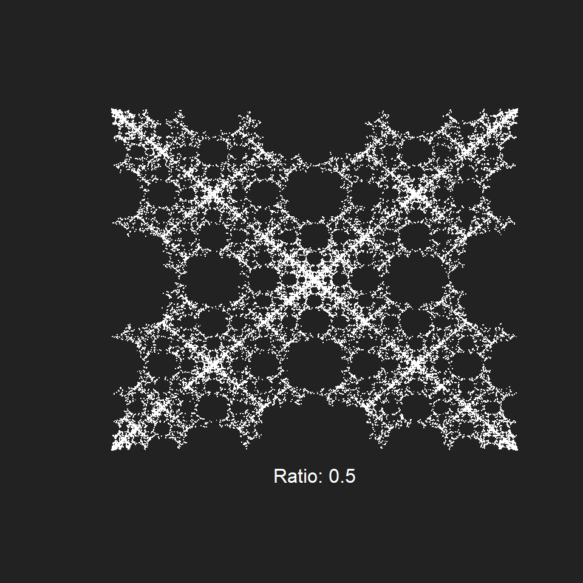

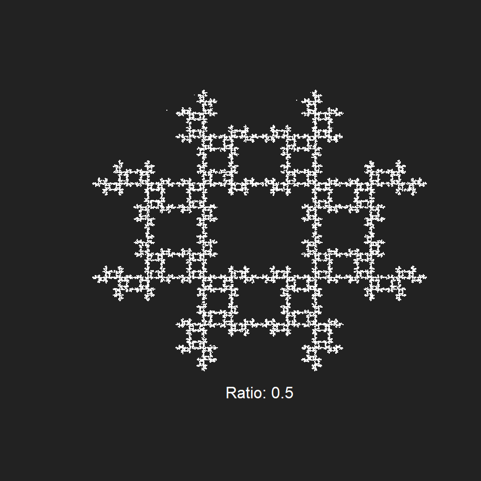

Pentagon

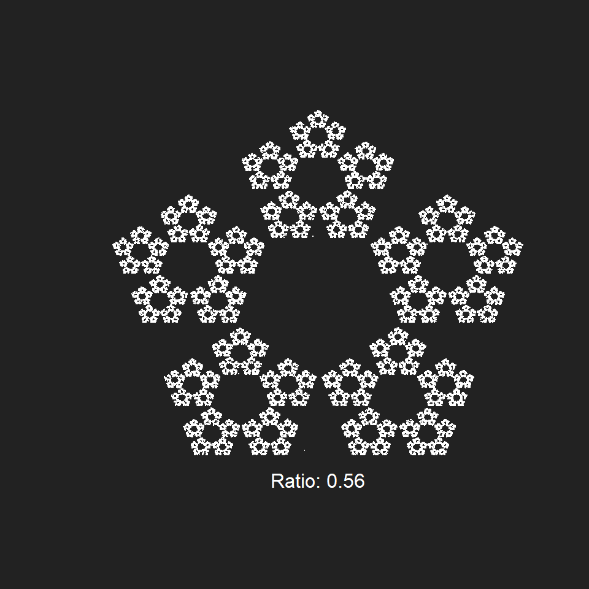

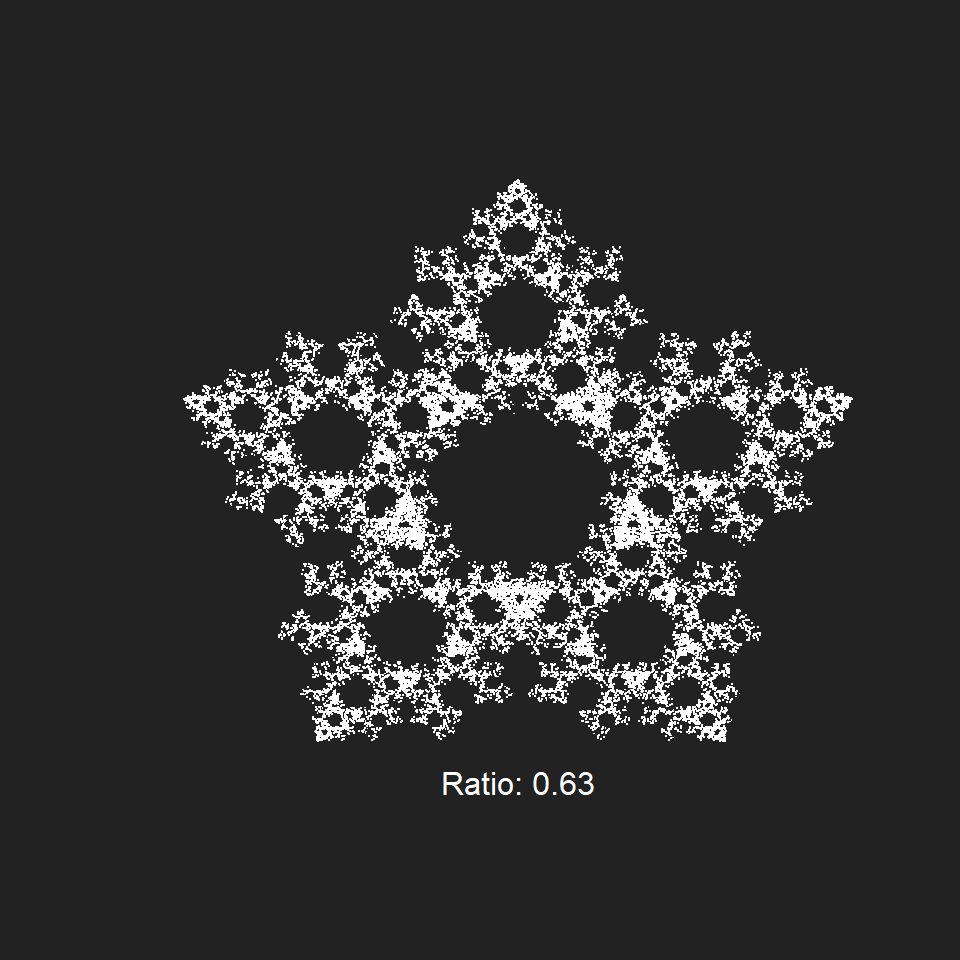

Hexagon

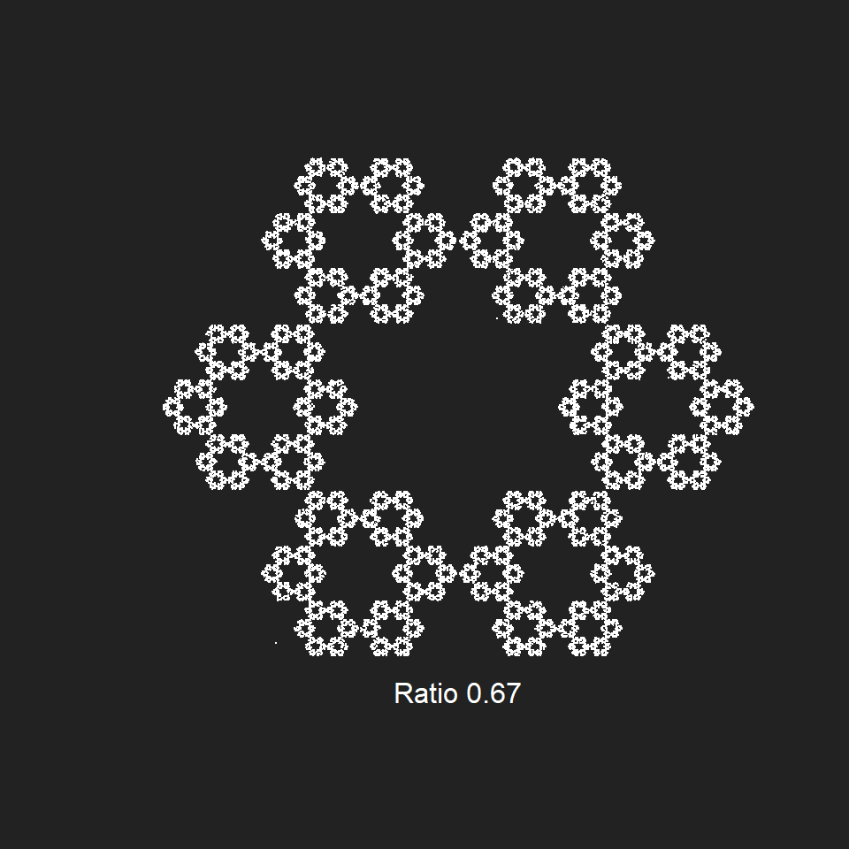

Barnsley’s Fern

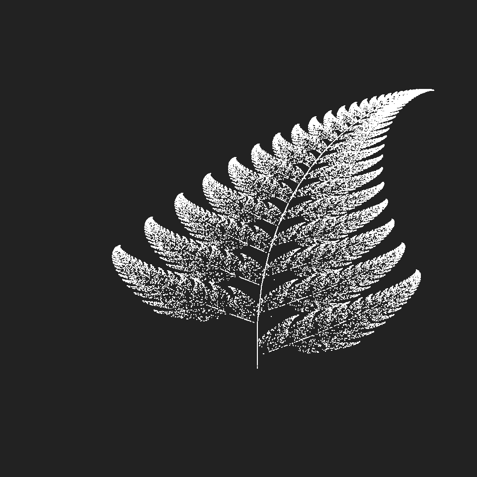

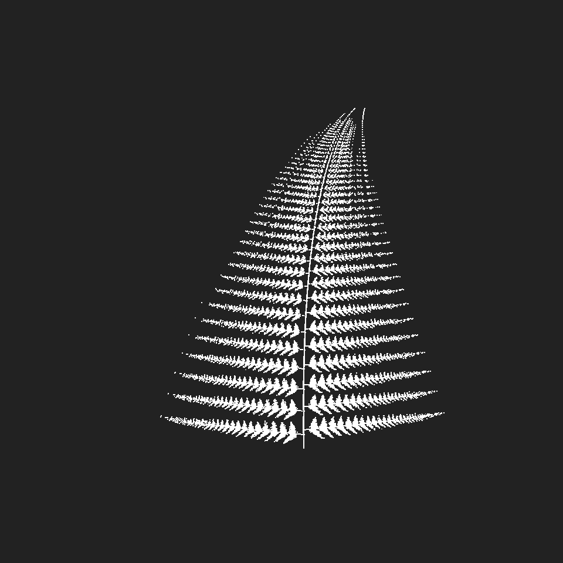

## Implementare:

```
library(shiny)
library(shape)
library(shinythemes)

# UI

NMAX <- 300000

ui <- fluidPage(
  theme = shinytheme("darkly"),
  titlePanel("Chaos Game"),

  sidebarLayout(
    sidebarPanel(
      wellPanel(
        selectizeInput('shape', h5(tags$b('Shape')), choices = list(
          "Two Dimensions" = c('Triangle' = 'triangle',
                               'Square' = 'square',
                               'Pentagon' = 'pentagon',
                               'Hexagon' = 'hexagon',
                               'Barnsley Fern' ='barnsleyFern')
        ), selected = 'triangle'),

        conditionalPanel(
          condition = "input.shape =='pentagon'",
          selectizeInput('ruleset', h5(tags$b('Rules')), choices = list(
            "Rules" = c('Rule 1' = 'rule1',
                        'Rule 2' = 'rule2')
          ), selected = 'rule1')),

        conditionalPanel(
          condition = "input.shape =='square'",
          selectizeInput('rulesetSquare', h5(tags$b('Rules')), choices = list(
            "Rules" = c('Rule 1' = 'rule1',
                        'Rule 2' = 'rule2',
                        'Rule 3' = 'rule3'
            )
          ), selected = 'rule1')),

        conditionalPanel(
```

[output cut: 500 more lines]

```
  })
  output$completePlot <- renderPlot({
    Vertices <- figure()[[1]]
    par(bg="#616161")
    Points <- figure()[[2]]
    plot(0, 0, xlim = c(0, 1), ylim = c(0, 1), col = 0, yaxt = "n", xaxt = "n", xlab = "", ylab = "", bty = "n")
    points(Points[1 : input$completeNrPoints - 1, 1], Points[1 : input$completeNrPoints - 1, 2], pch = 20, col="white")
    if(input$shape != "barnsleyFern")
    {
      points(Vertices[, 2], Vertices[, 3], pch = 20, cex = 3, col="#d1d1d1")
    }
  })
}

shinyApp(ui = ui, server = server)
```